# Natural variation of flight

Kyu Min Huh

2025-11-08

# Summary

We analysed 1434 flights of 49 individuals of blue tit, great tit, and marsh tit to identify interspecific differences in take-off flight performance. We found significant difference in initial velocity and in-flight acceleration between species. Great tits showed higher initial velocity and lower in-flight acceleration than blue tits. Marsh tits did not differ in flight performance with other species. Weather conditions did not show significant effect to flight performance.

# I. Data

## libraries

```r
library(dplyr)
library(stringr)
library(readr)
library(fuzzyjoin)
library(tidyverse)
library(ggplot2)
library(lubridate)
library(ggpubr)
library(rstatix)
library(coin)
library(scales)
library(gridExtra)
library(ggthemes)
library(ggbreak)
library(lme4)
library(reshape2)
library(olsrr)
library(gvlma)
library(PerformanceAnalytics)
library(usethis)
library(devtools)
library(redres)
library(EnvStats)
library(lmtest)
library(lmerTest)
library(AICcmodavg)
library(emmeans)
library(MuMIn)
library(sjPlot)
library(rptR)
```

## dataset

```r
all_dates3 <- read.delim(file = "C:\\Users\\jesu4036\\Documents\\GitHub\\wytham-tits-fly\\all_dates3.txt", sep = ",") %>% distinct()

all_dates3$datetime.y <- as.POSIXct(all_dates3$datetime.y, format = "%Y-%m-%d %H:%M:%S")
colnames(all_dates3)
```

```
##  [1] "Ring"        "RFID"        "datetime.y"  "temperature" "firstbreak1"
##  [6] "firstbreak2" "firstbreak3" "lastbreak1"  "lastbreak2"  "lastbreak3"
## [11] "t1"          "t2"          "v1"          "v2"          "avg.v"
## [16] "acc"         "section2"    "section3"    "section4"    "length1"
## [21] "length2"     "tunnel"      "species"     "age"         "Spec"
## [26] "Sex"         "Date"        "Place"       "Site"        "Wing"
## [31] "Wt"          "Init"        "Tarsus"
```

```r
all_dates3 <- all_dates3 %>%
  select(-Spec)

climate <- read.delim(file = "C:\\Users\\jesu4036\\Documents\\GitHub\\wytham-tits-fly\\climate_filled.csv", sep = ',')

climate$datetime <- as.POSIXct(climate$datetime, format = "%Y-%m-%d %H:%M:%S")

caught.hour.day <- read.delim(file = "C:\\Users\\jesu4036\\Documents\\GitHub\\wytham-tits-fly\\caught.hour.day.csv", sep = ',')
```

## adding day and hour and climate

```r
all_dates3$day <- day(all_dates3$datetime.y)
all_dates3$hour <- hour(all_dates3$datetime.y)

all_dates3$roundate <- round_date(all_dates3$datetime.y, "10 mins")
all_dates3.climate <- merge(x = all_dates3, y = climate, by.x = "roundate", by.y = "datetime", all.x = TRUE)

flight.data <- all_dates3.climate %>%
  filter(day %in% c(15:24))

nat.var <- all_dates3.climate %>%
  filter(day %in% c(15:19))

capt.eff <- all_dates3.climate %>%
  filter(day %in% c(20:24))
```

write.csv(nat.var, “C:\Users\kmh\Desktop\DATA\nat.var.csv”)

## data synopsis

### raw continuous data

```r
dim(flight.data) #total number of flight
```

```
## [1] 3451   38
```

```r
table(flight.data$day)
```

```
##
##  15  16  17  18  19  20  21  22  23  24
## 241 231  54 528 380 485 616 318 504  94
```

```r
no.of.individuals <- rowSums(table(flight.data$species, flight.data$Ring)!=0)
no.of.flights <- table(flight.data$species)

raw_sum <- rbind(no.of.individuals, no.of.flights)

raw_sum
```

```
##                   bluti greti marti
## no.of.individuals    40    16     5
## no.of.flights      2617   513   321
```

### natural variation data

```r
dim(nat.var) #total number of flight
```

```
## [1] 1434   38
```

```r
table(nat.var$day)
```

```
##
##  15  16  17  18  19
## 241 231  54 528 380
```

```r
no.of.individuals <- rowSums(table(nat.var$species, nat.var$Ring)!=0)
no.of.flights <- table(nat.var$species)

nat.var_sum <- rbind(no.of.individuals, no.of.flights)

nat.var_sum
```

```
##                   bluti greti marti
## no.of.individuals    33    12     4
## no.of.flights      1172   148   114
```

```r
breeding <- cbind(nat.var$Ring, nat.var$RFID, nat.var$species, nat.var$age, nat.var$Sex) %>% as.data.frame() %>%
  distinct()
colnames(breeding) <- c("Ring", "RFID", "species", "age", "Sex")
```

write.csv(breeding, “\breeding.csv”,row.names = FALSE )

### For each species, M vs. F, young vs. adult, then between species

```r
#find the ring number of those without Sex in Great Tit & Blue Tit
for( i in 1:nrow(nat.var)){

  if(nat.var$Ring[i] == "ATR8387"){

    nat.var$Sex[i] <- "F"
  }

  else if(nat.var$Ring[i] == "ATR8383"){

    nat.var$Sex[i] <- "F"
  }
  else if(nat.var$Ring[i] == "PF72506"){

    nat.var$Sex[i] <- "M"
  }
  else{}

}

#Sex unknown for ATR8380 and ATR5368 both in morphometrics and brood data
nosex <- nat.var %>%
  filter(species != "marti") %>%
  filter(Sex == "") %>%
  select(Ring) %>%
  distinct()
```

### no.of individuals by species, age, sex in natural variation

```r
numbers <- nat.var %>%
  count(species, age, Sex, Ring)


individual.age <- numbers %>%
  count(species, age)

individual.sex <- numbers %>%
  count(species, Sex)

numbers.age <- numbers %>%
   group_by(species, age) %>%
   summarise(mean = mean(n), sd = sd(n)) %>%
             na.omit()
numbers.sex <- numbers %>%
  group_by(species, Sex) %>%
  summarise(mean = mean(n), sd = sd(n)) %>%
            na.omit()
numbers.age <- numbers.age %>%
  add_column(individual.age$n)

numbers.sex <- numbers.sex %>%
  add_column(individual.sex$n)

numbers.tot <- numbers %>%
  group_by(species) %>%
  summarise(mean = mean(n), sd = sd(n)) %>%
            na.omit()

numbers.age
```

```
## # A tibble: 5 × 5
## # Groups:   species [3]
##   species   age  mean    sd `individual.age$n`
##   <chr>   <int> <dbl> <dbl>              <int>
## 1 bluti       5  33.6  24.6                 22
## 2 bluti       6  36    20.0                 12
## 3 greti       5  11.4  11.5                 10
## 4 greti       6  17    22.6                  2
## 5 marti       5  28.5  11.0                  4
```

```r
numbers.sex
```

```
## # A tibble: 6 × 5
## # Groups:   species [3]
##   species Sex    mean    sd `individual.sex$n`
##   <chr>   <chr> <dbl> <dbl>              <int>
## 1 bluti   ""     54.5  17.7                  2
## 2 bluti   "F"    33.7  18.9                 15
## 3 bluti   "M"    32.8  26.2                 17
## 4 greti   "F"    15.8  17.4                  4
## 5 greti   "M"    10.6  10.5                  8
## 6 marti   ""     28.5  11.0                  4
```

```r
numbers.tot
```

```
## # A tibble: 3 × 3
##   species  mean    sd
##   <chr>   <dbl> <dbl>
## 1 bluti    34.5  22.8
## 2 greti    12.3  12.6
## 3 marti    28.5  11.0
```

#### t-tests on visiting rate

```r
bluti <- numbers %>%
  filter(species == "bluti")

greti <- numbers %>%
  filter(species == "greti")

marti <- numbers %>%
  filter(species == "marti")



bluti.F <- numbers %>%
   filter(species == "bluti" & Sex == "F")

bluti.M <- numbers %>%
   filter(species == "bluti" & Sex == "M")

bluti.5 <- numbers %>%
   filter(species == "bluti" & age == 5)

bluti.6 <- numbers %>%
   filter(species == "bluti" & age == 6)

greti.F <- numbers %>%
  filter(species == "greti" & Sex == "F")

greti.M <- numbers %>%
  filter(species == "greti" & Sex == "M")

greti.5 <- numbers %>%
  filter(species == "greti" & age == 5)

greti.6 <- numbers %>%
  filter(species == "greti" & age == 6)

t.test(bluti.F$n, bluti.M$n, paired = FALSE, var.equal = FALSE, conf.level = 0.95)
```

```
##
##  Welch Two Sample t-test
##
## data:  bluti.F$n and bluti.M$n
## t = 0.10527, df = 28.948, p-value = 0.9169
## alternative hypothesis: true difference in means is not equal to 0
## 95 percent confidence interval:
##  -15.53856  17.22483
## sample estimates:
## mean of x mean of y
##  33.66667  32.82353
```

```r
t.test(bluti.5$n, bluti.6$n, paired = FALSE, var.equal = FALSE, conf.level = 0.95)
```

```
##
##  Welch Two Sample t-test
##
## data:  bluti.5$n and bluti.6$n
## t = -0.30328, df = 27.045, p-value = 0.764
## alternative hypothesis: true difference in means is not equal to 0
## 95 percent confidence interval:
##  -18.35356  13.62629
## sample estimates:
## mean of x mean of y
##  33.63636  36.00000
```

```r
t.test(greti.F$n, greti.M$n, paired = FALSE, var.equal = FALSE, conf.level = 0.95)
```

```
##
##  Welch Two Sample t-test
##
## data:  greti.F$n and greti.M$n
## t = 0.5423, df = 4.1323, p-value = 0.6155
## alternative hypothesis: true difference in means is not equal to 0
## 95 percent confidence interval:
##  -20.7855  31.0355
## sample estimates:
## mean of x mean of y
##    15.750    10.625
```

```r
t.test(greti.5$n, greti.6$n, paired = FALSE, var.equal = FALSE, conf.level = 0.95)
```

```
##
##  Welch Two Sample t-test
##
## data:  greti.5$n and greti.6$n
## t = -0.34135, df = 1.1049, p-value = 0.7863
## alternative hypothesis: true difference in means is not equal to 0
## 95 percent confidence interval:
##  -172.6219  161.4219
## sample estimates:
## mean of x mean of y
##      11.4      17.0
```

```r
t.test(bluti$n, greti$n, paired = FALSE, var.equal = FALSE, conf.level = 0.95)
```

```
##
##  Welch Two Sample t-test
##
## data:  bluti$n and greti$n
## t = 4.146, df = 35.353, p-value = 0.0002014
## alternative hypothesis: true difference in means is not equal to 0
## 95 percent confidence interval:
##  11.30160 32.97291
## sample estimates:
## mean of x mean of y
##  34.47059  12.33333
```

```r
t.test(bluti$n, marti$n, paired = FALSE, var.equal = FALSE, conf.level = 0.95)
```

```
##
##  Welch Two Sample t-test
##
## data:  bluti$n and marti$n
## t = 0.88326, df = 6.6185, p-value = 0.408
## alternative hypothesis: true difference in means is not equal to 0
## 95 percent confidence interval:
##  -10.20223  22.14341
## sample estimates:
## mean of x mean of y
##  34.47059  28.50000
```

```r
t.test(greti$n, marti$n, paired = FALSE, var.equal = FALSE, conf.level = 0.95)
```

```
##
##  Welch Two Sample t-test
##
## data:  greti$n and marti$n
## t = -2.447, df = 5.8748, p-value = 0.05085
## alternative hypothesis: true difference in means is not equal to 0
## 95 percent confidence interval:
##  -32.41668686   0.08335352
## sample estimates:
## mean of x mean of y
##  12.33333  28.50000
```

#### headwind, air temperature, humidity

```r
#overall climate data
#find how many weather values are missing
#missing data that do not make to the final dataset.
View(flight.data[!complete.cases(flight.data),])
#mean weather

mean(flight.data$air.temp, na.rm = TRUE)
```

```
## [1] 9.096442
```

```r
mean(flight.data$headwind, na.rm = TRUE) #relative to the birds flying out of the tunnel
```

```
## [1] -1.428632
```

```r
mean(flight.data$humidity, na.rm = TRUE)
```

```
## [1] 80.46904
```

```r
#dataset for baseline variation
climate.nat.var <- nat.var %>%
  filter(day %in% c(15:19)) %>%
  select(headwind, air.temp, humidity)

#not using caught.hour.day which is a reduced dataset to just answer the question if the climate conditions were different at nat.var vs. capt.eff
#otherwise everything is significant probably the sample size is so vastly different
climate.capt.eff <- caught.hour.day %>%
  select(headwind, air.temp, humidity)

#mean of nat.var. # 2 for columns
apply(climate.nat.var, 2,mean)
```

```
##  headwind  air.temp  humidity
## -3.169797 10.976903 78.366511
```

```r
#sd of nat.var
apply(climate.nat.var, 2, sd)
```

```
## headwind air.temp humidity
## 1.040167 1.553028 9.631564
```

```r
#mean of capt.eff
apply(climate.capt.eff, 2, mean, na.rm = TRUE)
```

```
##  headwind  air.temp  humidity
##  2.300897  6.819277 72.716639
```

```r
#mean of capt.eff
apply(climate.capt.eff, 2, sd, na.rm = TRUE)
```

```
##  headwind  air.temp  humidity
## 2.1071941 0.9258642 5.7299068
```

```r
climate.all <- nat.var %>%
  filter(day %in% c(15:24)) %>%
  select(headwind, air.temp, humidity)

apply(climate.all, 2, mean)
```

```
##  headwind  air.temp  humidity
## -3.169797 10.976903 78.366511
```

```r
apply(climate.all, 2, sd)
```

```
## headwind air.temp humidity
## 1.040167 1.553028 9.631564
```

```r
caught.byday <- caught.hour.day %>%
  group_by(cgt_day) %>%
  summarise(mean.hdw = mean(headwind, na.rm = FALSE),
            mean.art = mean(air.temp, na.rm = FALSE),
            mean.hmd = mean(humidity, na.rm = FALSE),
            sd.hdw = sd(headwind, na.rm = FALSE),
            sd.art = sd(air.temp, na.rm = FALSE),
            sd.hmd = sd(humidity, na.rm = FALSE),
            max.hdw = max(headwind, na.rm = FALSE),
            min.hdw = min(headwind, na.rm = FALSE)
            ) %>%
            na.omit()


caught.byday
```

```
## # A tibble: 2 × 9
##   cgt_day mean.hdw mean.art mean.hmd sd.hdw sd.art sd.hmd max.hdw min.hdw
##     <int>    <dbl>    <dbl>    <dbl>  <dbl>  <dbl>  <dbl>   <dbl>   <dbl>
## 1       0    0.156     7.58     75.8  1.53   0.774   5.46    4.83   -1.05
## 2       1    3.71      6.32     70.7  0.894  0.633   4.98    5.47    1.99
```

```r
day0 <- caught.hour.day %>%
          filter(cgt_day == 0)

day1 <- caught.hour.day %>%
          filter(cgt_day == 1)

t.test(day0$headwind, day1$headwind, paired = FALSE, var.equal = FALSE, conf.level = 0.95)
```

```
##
##  Welch Two Sample t-test
##
## data:  day0$headwind and day1$headwind
## t = -18.211, df = 107.5, p-value < 2.2e-16
## alternative hypothesis: true difference in means is not equal to 0
## 95 percent confidence interval:
##  -3.942435 -3.168404
## sample estimates:
## mean of x mean of y
## 0.1563588 3.7117780
```

```r
t.test(day0$air.temp, day1$air.temp, paired = FALSE, var.equal = FALSE, conf.level = 0.95)
```

```
##
##  Welch Two Sample t-test
##
## data:  day0$air.temp and day1$air.temp
## t = 11.723, df = 136.2, p-value < 2.2e-16
## alternative hypothesis: true difference in means is not equal to 0
## 95 percent confidence interval:
##  1.045330 1.469544
## sample estimates:
## mean of x mean of y
##  7.577731  6.320294
```

```r
t.test(day0$humidity, day1$humidity, paired = FALSE, var.equal = FALSE, conf.level = 0.95)
```

```
##
##  Welch Two Sample t-test
##
## data:  day0$humidity and day1$humidity
## t = 6.4736, df = 148.01, p-value = 1.323e-09
## alternative hypothesis: true difference in means is not equal to 0
## 95 percent confidence interval:
##  3.527083 6.626559
## sample estimates:
## mean of x mean of y
##  75.77885  70.70203
```

```r
t.test(climate.nat.var$headwind, climate.capt.eff$headwind, paired = FALSE, var.equal = FALSE, conf.level = 0.95)
```

```
##
##  Welch Two Sample t-test
##
## data:  climate.nat.var$headwind and climate.capt.eff$headwind
## t = -35.132, df = 200.24, p-value < 2.2e-16
## alternative hypothesis: true difference in means is not equal to 0
## 95 percent confidence interval:
##  -5.777751 -5.163637
## sample estimates:
## mean of x mean of y
## -3.169797  2.300897
```

```r
t.test(climate.nat.var$air.temp, climate.capt.eff$air.temp, paired = FALSE, var.equal = FALSE, conf.level = 0.95)
```

```
##
##  Welch Two Sample t-test
##
## data:  climate.nat.var$air.temp and climate.capt.eff$air.temp
## t = 52.727, df = 347.02, p-value < 2.2e-16
## alternative hypothesis: true difference in means is not equal to 0
## 95 percent confidence interval:
##  4.002540 4.312713
## sample estimates:
## mean of x mean of y
## 10.976903  6.819277
```

```r
t.test(climate.nat.var$humidity, climate.capt.eff$humidity, paired = FALSE, var.equal = FALSE, conf.level = 0.95)
```

```
##
##  Welch Two Sample t-test
##
## data:  climate.nat.var$humidity and climate.capt.eff$humidity
## t = 11.571, df = 347.77, p-value < 2.2e-16
## alternative hypothesis: true difference in means is not equal to 0
## 95 percent confidence interval:
##  4.689545 6.610200
## sample estimates:
## mean of x mean of y
##  78.36651  72.71664
```

### duration difference

```r
raw.flight.metrics <- nat.var %>%
  group_by(species) %>%
  summarise(mean.v1 = mean(v1, na.rm = FALSE),
            mean.v2 = mean(v2, na.rm = FALSE),
            mean.acc = mean(acc, na.rm = FALSE),
            mean.avg.v = mean(avg.v, na.rm = FALSE),
            mean.t1 = mean(t1, na.rm = FALSE),
            mean.t2 = mean(t2, na.rm = FALSE),
            mean.t3 = mean((t1+t2), na.rm = FALSE),
            sd.v1 = sd(v1, na.rm = FALSE),
            sd.v2 = sd(v2, na.rm = FALSE),
            sd.acc = sd(acc, na.rm = FALSE),
            sd.avg.v = sd(avg.v, na.rm = FALSE),
            sd.t1 = sd(t1, na.rm = FALSE),
            sd.t2 = sd(t2, na.rm = FALSE),
            sd.t3 = sd((t1+t2), na.rm = FALSE)
            ) %>%
            na.omit()

raw.flight.metrics
```

```
## # A tibble: 3 × 15
##   species mean.v1 mean.v2 mean.acc mean.avg.v mean.t1 mean.t2 mean.t3 sd.v1
##   <chr>     <dbl>   <dbl>    <dbl>      <dbl>   <dbl>   <dbl>   <dbl> <dbl>
## 1 bluti      2.53    2.94   3.89         2.71   107.     105.    212. 0.451
## 2 greti      2.84    2.87  -0.0160       2.83    97.4    108.    206. 0.624
## 3 marti      2.62    2.85   1.96         2.71   106.     108.    214. 0.511
## # ℹ 6 more variables: sd.v2 <dbl>, sd.acc <dbl>, sd.avg.v <dbl>, sd.t1 <dbl>,
## #   sd.t2 <dbl>, sd.t3 <dbl>
```

```r
bluti.raw <- nat.var %>%
  filter(species == "bluti") %>%
  mutate(t3 = t1 + t2)

greti.raw <- nat.var %>%
  filter(species == "greti") %>%
  mutate(t3 = t1 + t2)





t.test(bluti.raw$t1, greti.raw$t1, paired = FALSE, var.equal = FALSE, conf.level = 0.95)
```

```
##
##  Welch Two Sample t-test
##
## data:  bluti.raw$t1 and greti.raw$t1
## t = 3.943, df = 192.45, p-value = 0.0001126
## alternative hypothesis: true difference in means is not equal to 0
## 95 percent confidence interval:
##   4.857541 14.581072
## sample estimates:
## mean of x mean of y
## 107.13823  97.41892
```

```r
t.test(bluti.raw$t2, greti.raw$t2, paired = FALSE, var.equal = FALSE, conf.level = 0.95)
```

```
##
##  Welch Two Sample t-test
##
## data:  bluti.raw$t2 and greti.raw$t2
## t = -1.6142, df = 207.97, p-value = 0.108
## alternative hypothesis: true difference in means is not equal to 0
## 95 percent confidence interval:
##  -7.0957960  0.7070403
## sample estimates:
## mean of x mean of y
##  104.9881  108.1824
```

```r
t.test(bluti.raw$t3, greti.raw$t3, paired = FALSE, var.equal = FALSE, conf.level = 0.95)
```

```
##
##  Welch Two Sample t-test
##
## data:  bluti.raw$t3 and greti.raw$t3
## t = 1.6545, df = 188.86, p-value = 0.09969
## alternative hypothesis: true difference in means is not equal to 0
## 95 percent confidence interval:
##  -1.25462 14.30448
## sample estimates:
## mean of x mean of y
##  212.1263  205.6014
```

write.csv(raw.flight.metrics, “raw.flight.metrics.csv”,row.names = FALSE )

# II. Graphs

## A. Structural variation

### 1. individual variation

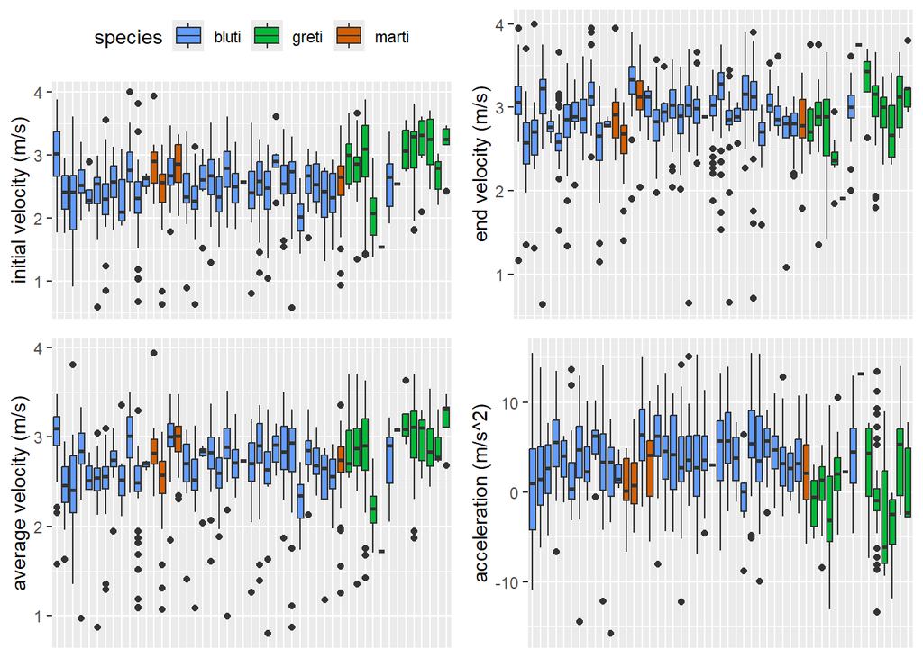

### 2. species variation

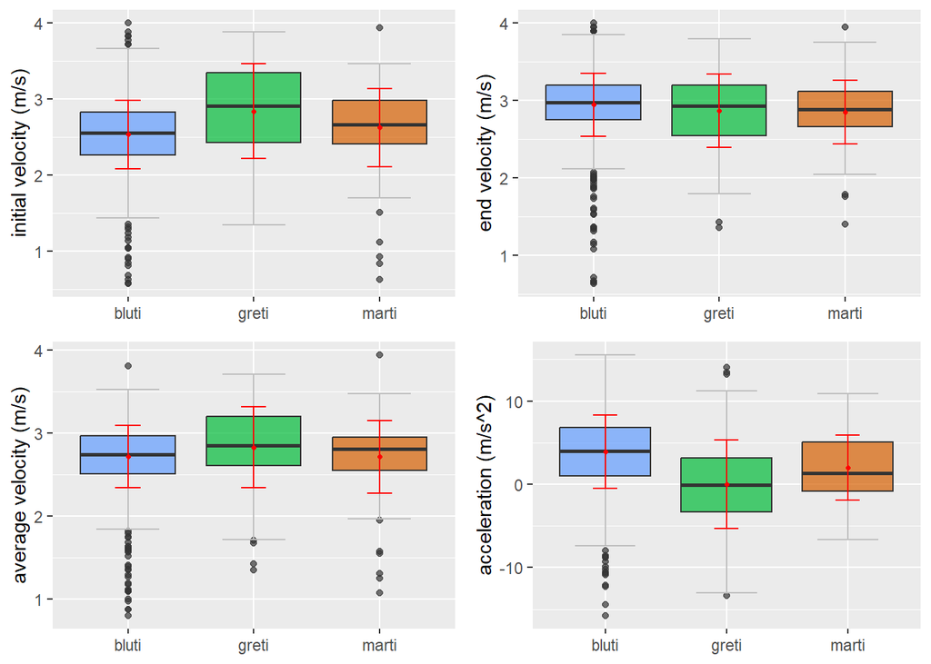

### 3. sex x species variation

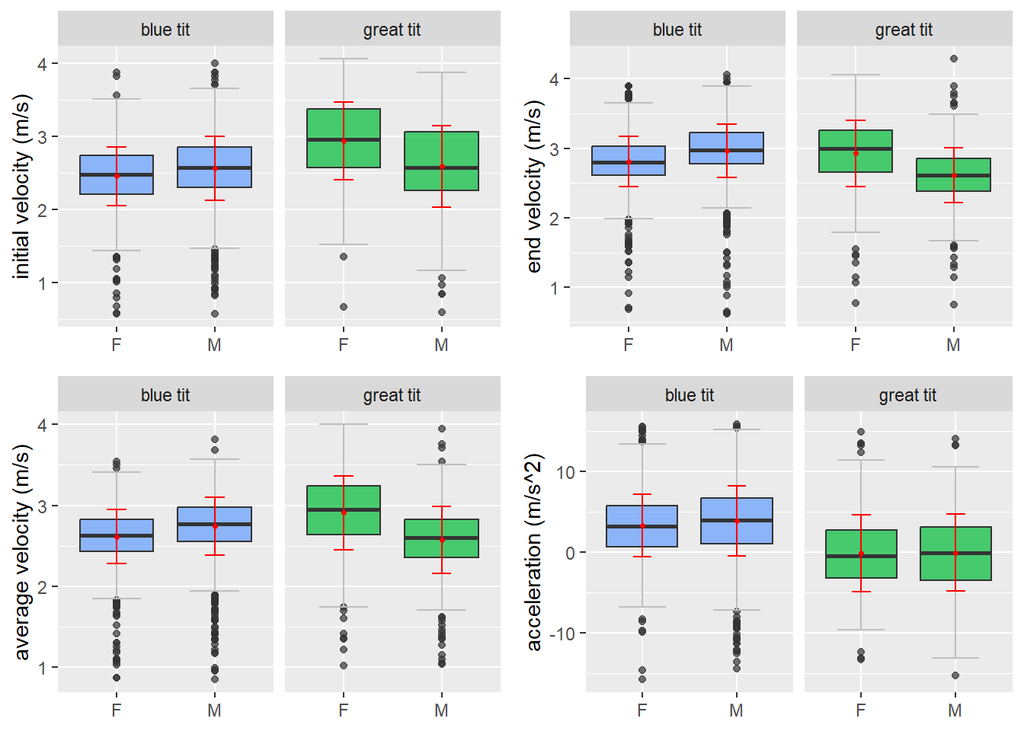

### 4. age variation

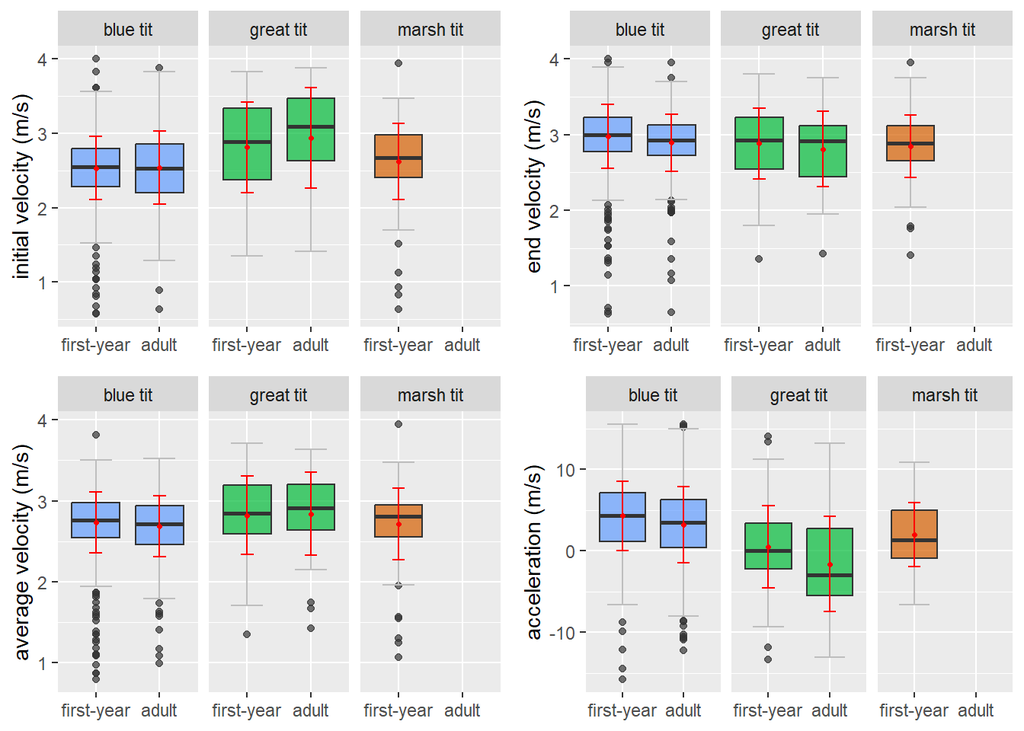

## B. climate factors

### 1. headwind

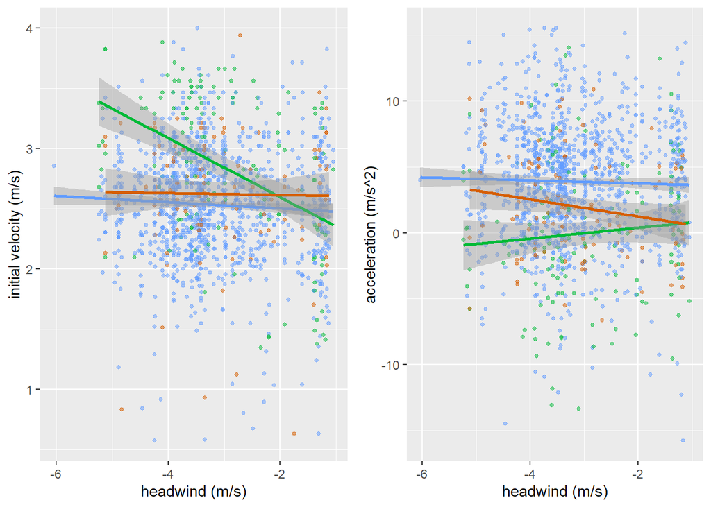

### 2. air temperature

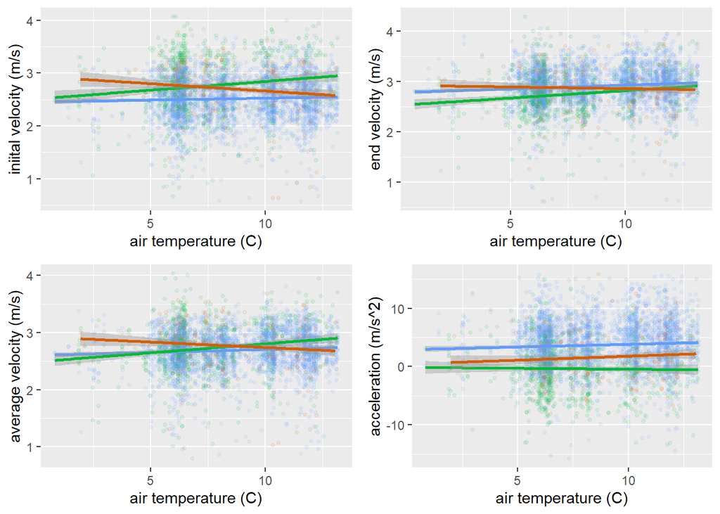

### 3. humidity

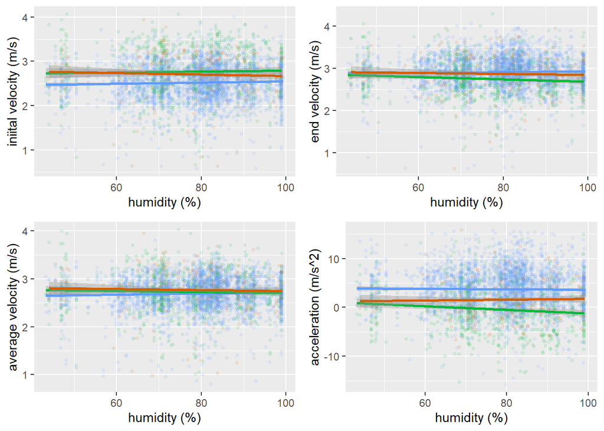

## C. diurnal variation

day effect not included in linear or linear mixed models because there was no difference among days until mist-netting happened.

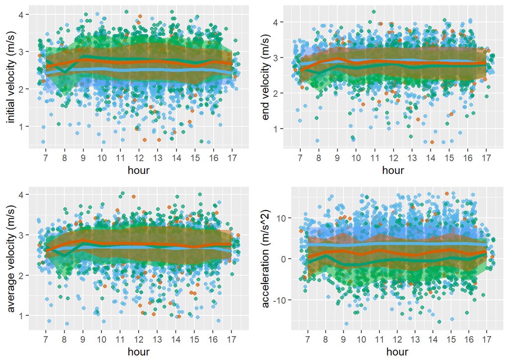

# III. Linear Mixed Model analysis

We chose linear mixed model to account for individual variation in flight speed. We chose headwind from climate factors by its relationship with flight and correlation with air temperature and humidity.

## A. Model selection

### 1. checking correlations

```
##  [1] "roundate"    "Ring"        "RFID"        "datetime.y"  "temperature"
##  [6] "firstbreak1" "firstbreak2" "firstbreak3" "lastbreak1"  "lastbreak2"
## [11] "lastbreak3"  "t1"          "t2"          "v1"          "v2"
## [16] "avg.v"       "acc"         "section2"    "section3"    "section4"
## [21] "length1"     "length2"     "tunnel"      "species"     "age"
## [26] "Sex"         "Date"        "Place"       "Site"        "Wing"
## [31] "Wt"          "Init"        "Tarsus"      "day"         "hour"
## [36] "air.temp"    "headwind"    "humidity"
```

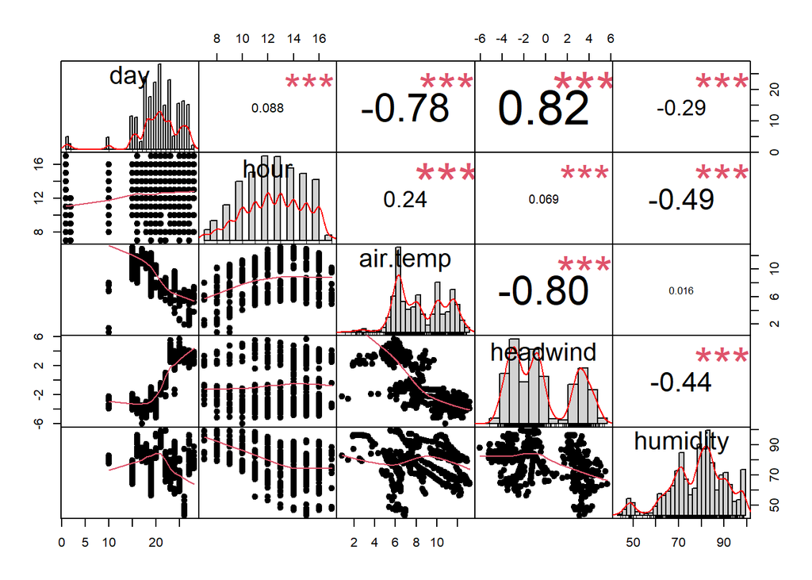

### 2. Proposed Mixed Linear Models.

#### with headwind

```r
lmer.v1 = lmer(v1 ~ species  + Sex  + age + headwind + (1|Ring), data = nat.var)
lmer.v2 = lmer(v2 ~species  + Sex  + age + headwind + (1|Ring), data = nat.var)
lmer.avg.v = lmer(avg.v ~ species  + Sex  + age + headwind + (1|Ring), data = nat.var)
lmer.acc = lmer(acc ~ species  + Sex  + age + headwind + (1|Ring), data = nat.var)
```

#### with air temperature

```r
lmer.v1 = lmer(v1 ~ species  + Sex  + age + air.temp + (1|Ring), data = nat.var)
lmer.v2 = lmer(v2 ~species  + Sex  + age + air.temp + (1|Ring), data = nat.var)
lmer.avg.v = lmer(avg.v ~ species  + Sex  + age + air.temp + (1|Ring), data = nat.var)
lmer.acc = lmer(acc ~ species  + Sex  + age + air.temp + (1|Ring), data = nat.var)
```

### 3. preparing dataset without outliers

We then identified 15 outliers using Rosner’s Test(1983) and prepared a dataset excluding outliers to see the sensitivity of the models to the outliers. All the outliers were included in the dataset in the end as we could not confirm that these outliers were from measurement errors.

```r
test.v1 <- rosnerTest(nat.var$v1, k=3)
test.v1$all.stats

test.v2 <- rosnerTest(nat.var$v2, k=10)
test.v2$all.stats

test.avg.v<- rosnerTest(nat.var$avg.v, k=13)
test.avg.v$all.stats

test.acc <- rosnerTest(nat.var$acc, k=3)
test.acc$all.stats

#collecting outlier row numbers
out.v1 <- test.v1$all.stats %>%
  filter(Outlier == "TRUE") %>%
  select(Obs.Num)

out.v2 <- test.v2$all.stats %>%
  filter(Outlier == "TRUE") %>%
  select(Obs.Num)

out.avg.v <- test.avg.v$all.stats %>%
  filter(Outlier == "TRUE") %>%
  select(Obs.Num)

out.acc <- test.acc$all.stats %>%
  filter(Outlier == "TRUE") %>%
  select(Obs.Num)
```

#### outliers

```r
outliers <- rbind(out.v1, out.v2, out.avg.v, out.acc) %>% distinct()
outliers #15 outliers
```

```
##    Obs.Num
## 1     1014
## 2      243
## 3     1318
## 4      951
## 5     1088
## 6     1177
## 7       27
## 8     1333
## 9      351
## 10     861
## 11    1222
## 12    1257
## 13    1207
## 14    1315
## 15     195
```

#### without outliers

```r
nat.var.out <- nat.var[-c(outliers$Obs.Num),]
dim(nat.var.out) #1419 observations
```

```
## [1] 1419   38
```

## B. Linear mixed model assumptions

### 1. normality tests

```r
# Computes the default residuals (raw conditional)
raw_cond.v1 <- compute_redres(lmer.v1)
raw_cond.v2 <- compute_redres(lmer.v2)
raw_cond.avg.v <- compute_redres(lmer.avg.v)
raw_cond.acc <- compute_redres(lmer.acc)
```

#### initial velocity

```r
shapiro.test(raw_cond.v1) #p <0.05
```

```
##
##  Shapiro-Wilk normality test
##
## data:  raw_cond.v1
## W = 0.9694, p-value < 2.2e-16
```

#### end velocity

```r
shapiro.test(raw_cond.v2) #p <0.05
```

```
##
##  Shapiro-Wilk normality test
##
## data:  raw_cond.v2
## W = 0.89926, p-value < 2.2e-16
```

#### average velocity

```r
shapiro.test(raw_cond.avg.v) #p <0.05
```

```
##
##  Shapiro-Wilk normality test
##
## data:  raw_cond.avg.v
## W = 0.89764, p-value < 2.2e-16
```

```r
shapiro.test(raw_cond.acc) #p <0.05
```

```
##
##  Shapiro-Wilk normality test
##
## data:  raw_cond.acc
## W = 0.99357, p-value = 7.024e-06
```

### 2. checking assumption graphs

#### initial velocity

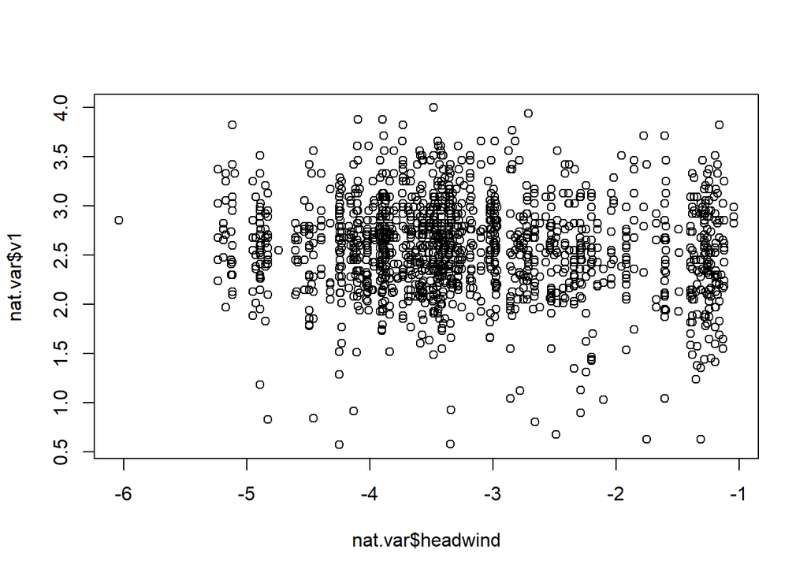

```r
plot(nat.var$headwind, nat.var$v1) #linearity
```

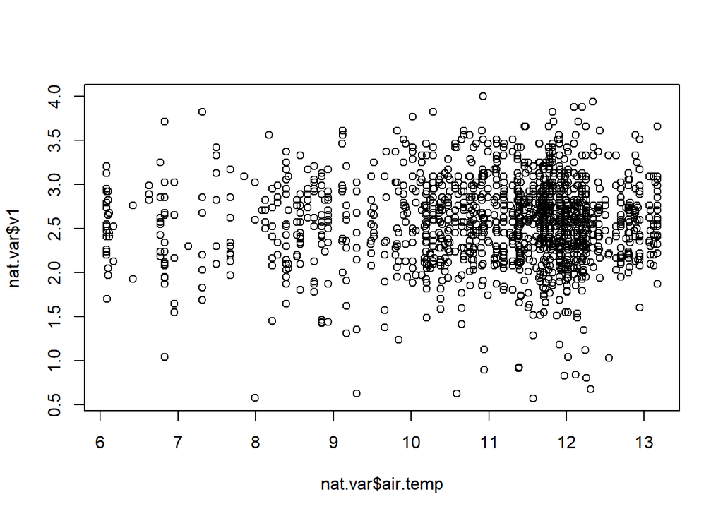

```r
plot(nat.var$air.temp, nat.var$v1) #linearity
```

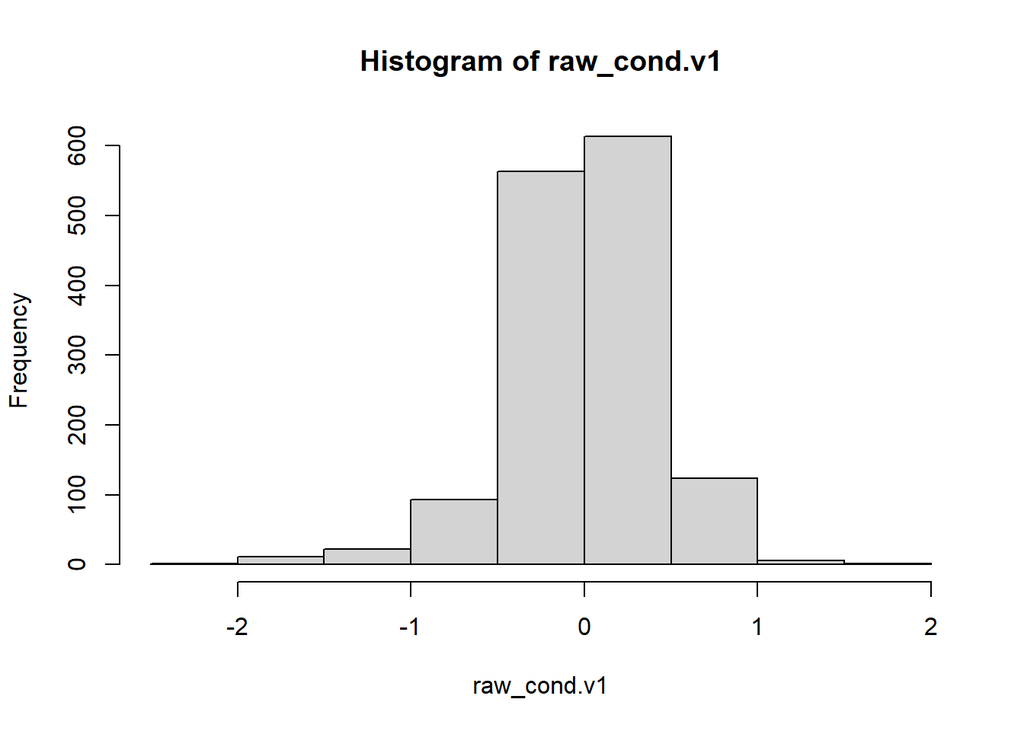

```r
hist(raw_cond.v1) #normality in histogram
```

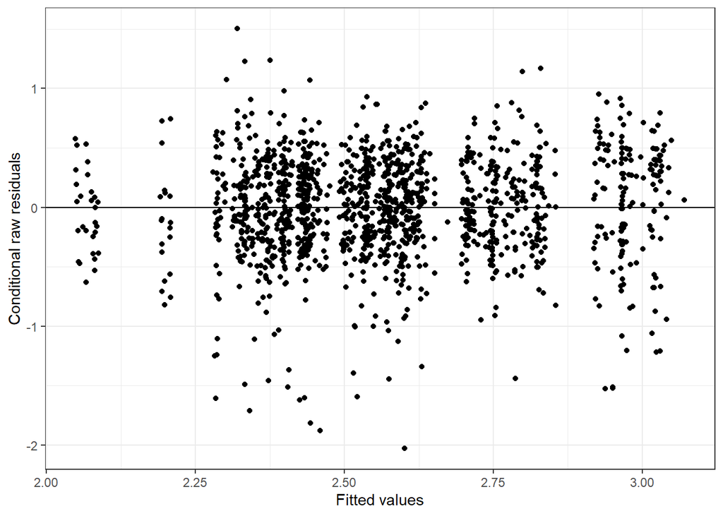

```r
plot_redres(lmer.v1) #heteroskedasticity
```

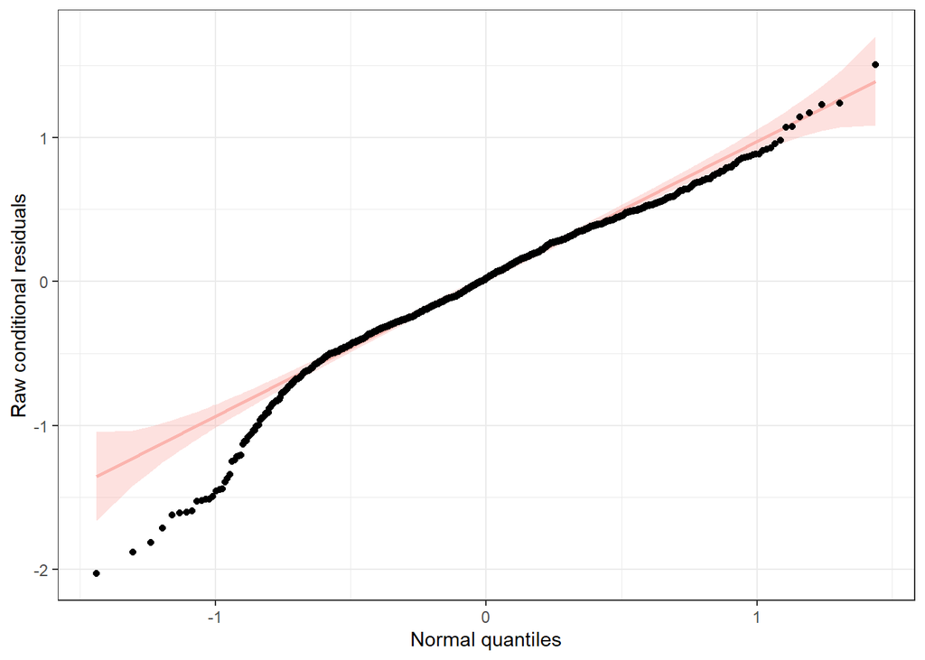

```r
plot_resqq(lmer.v1) #normality of residuals
```

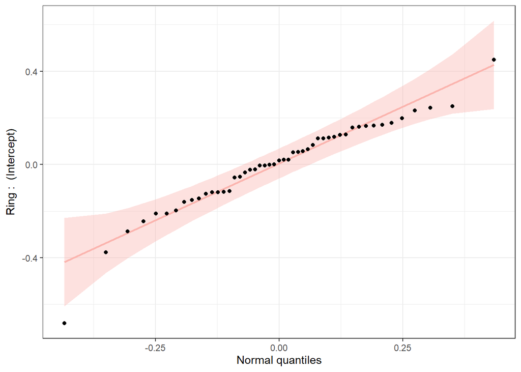

```r
plot_ranef(lmer.v1) #normality of random effects residuals
```

#### end velocity

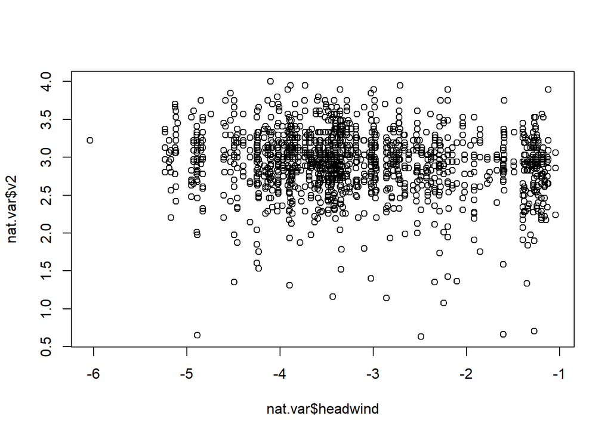

```r
plot(nat.var$headwind, nat.var$v2)
```

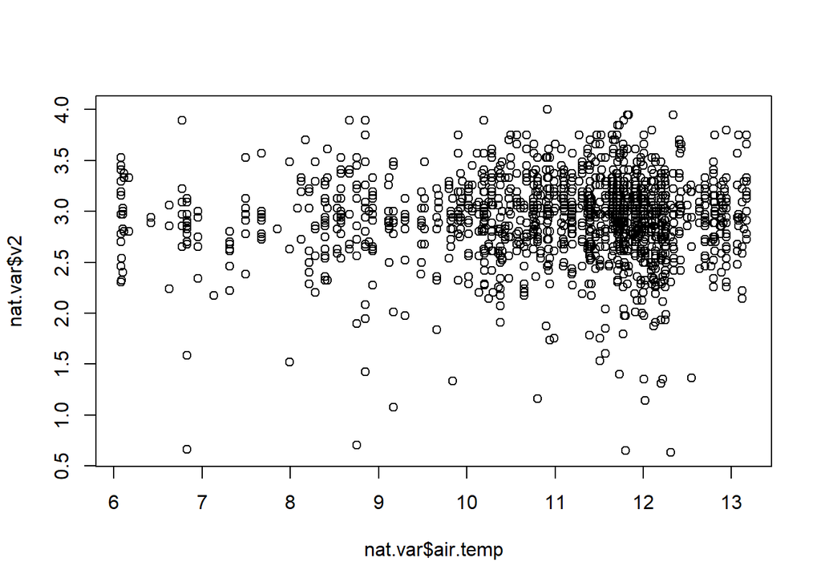

```r
plot(nat.var$air.temp, nat.var$v2) #wider range
```

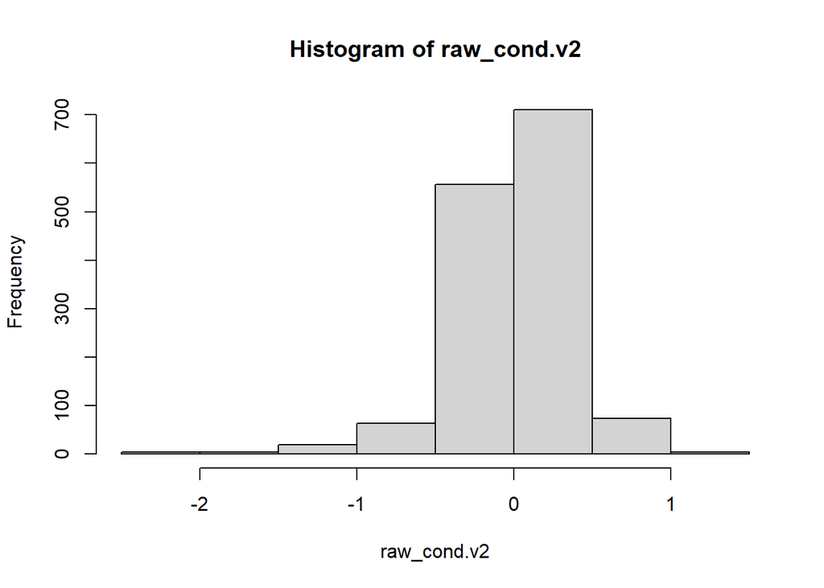

```r
hist(raw_cond.v2) #normality in histogram
```

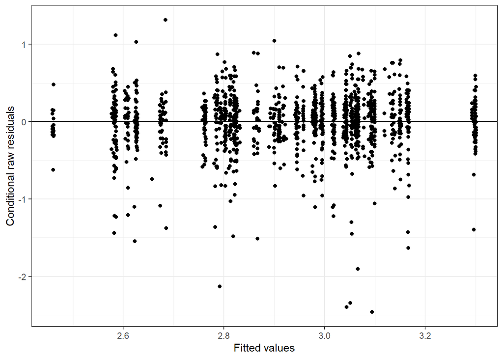

```r
plot_redres(lmer.v2) #heteroskedasticity
```

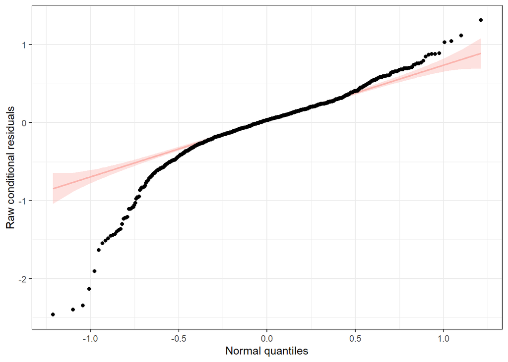

```r
plot_resqq(lmer.v2) #normality of residuals. not great..
```

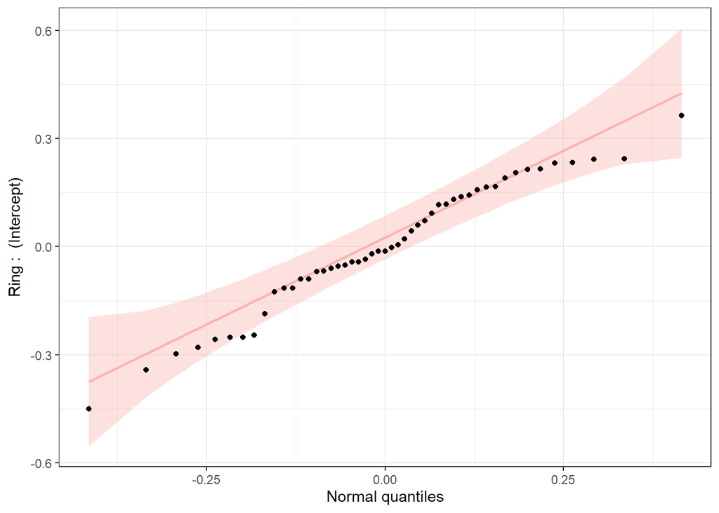

```r
plot_ranef(lmer.v2) #normality of random effects residuals
```

#### average velocity

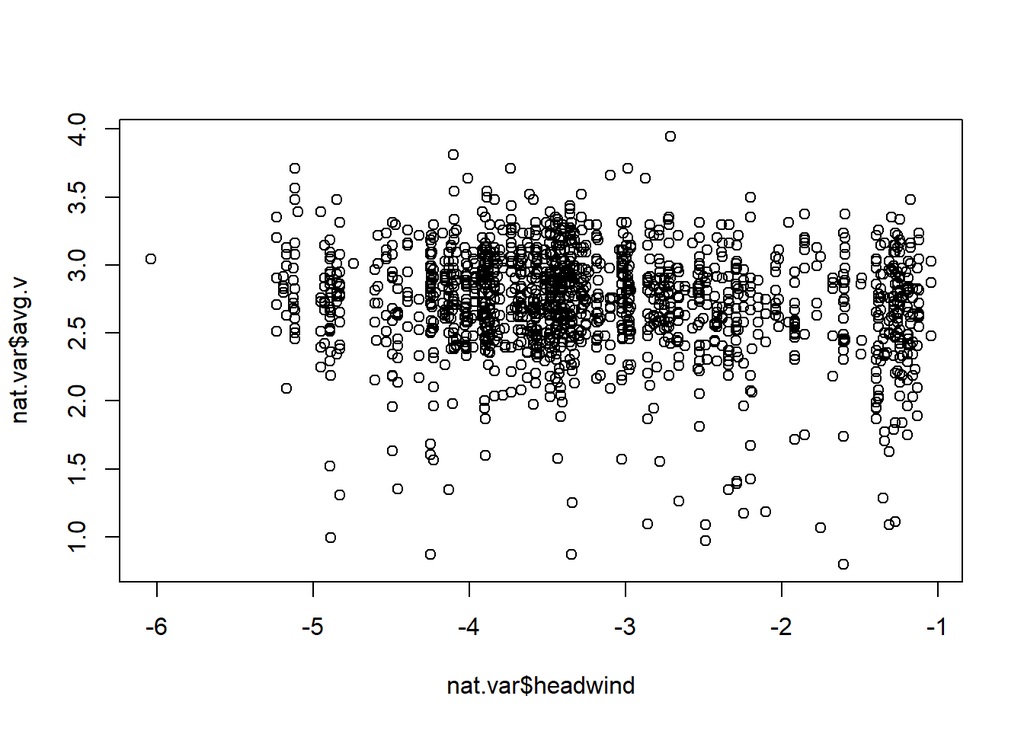

```r
plot(nat.var$headwind, nat.var$avg.v)
```

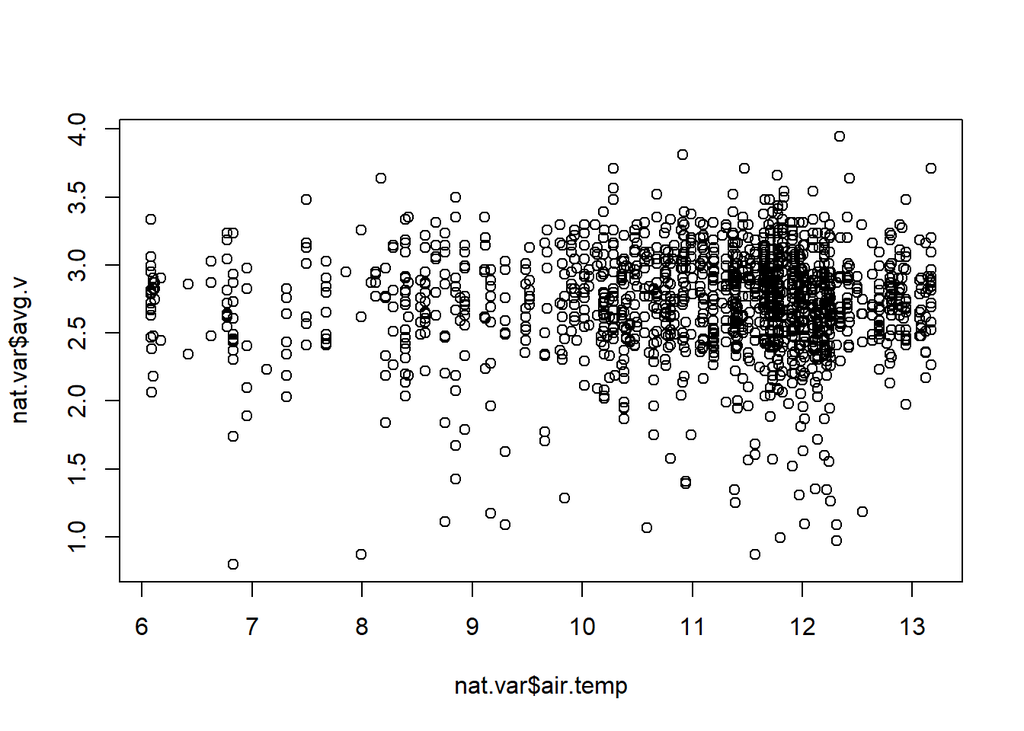

```r
plot(nat.var$air.temp, nat.var$avg.v)
```

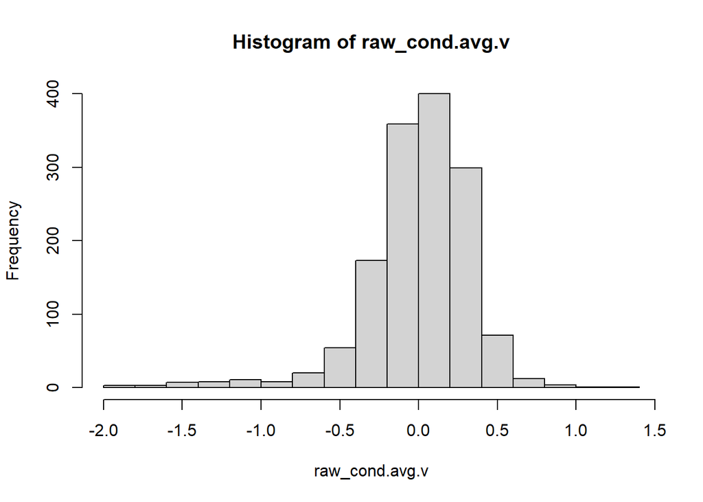

```r
hist(raw_cond.avg.v) #normality in histogram
```

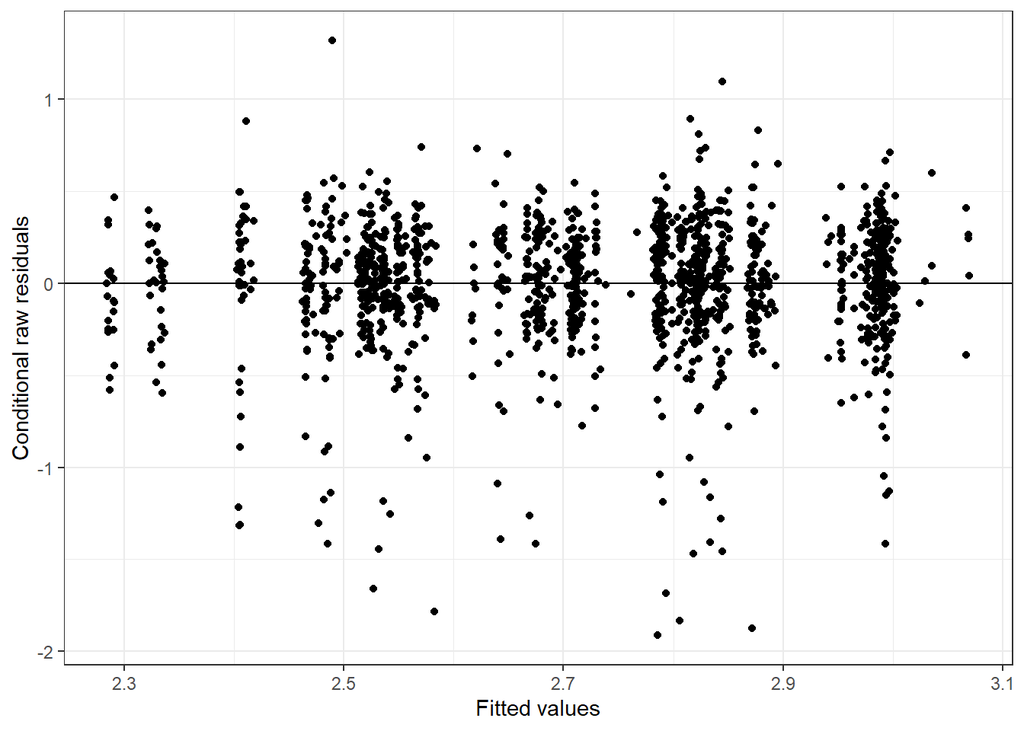

```r
plot_redres(lmer.avg.v) #heteroskedasticity
```

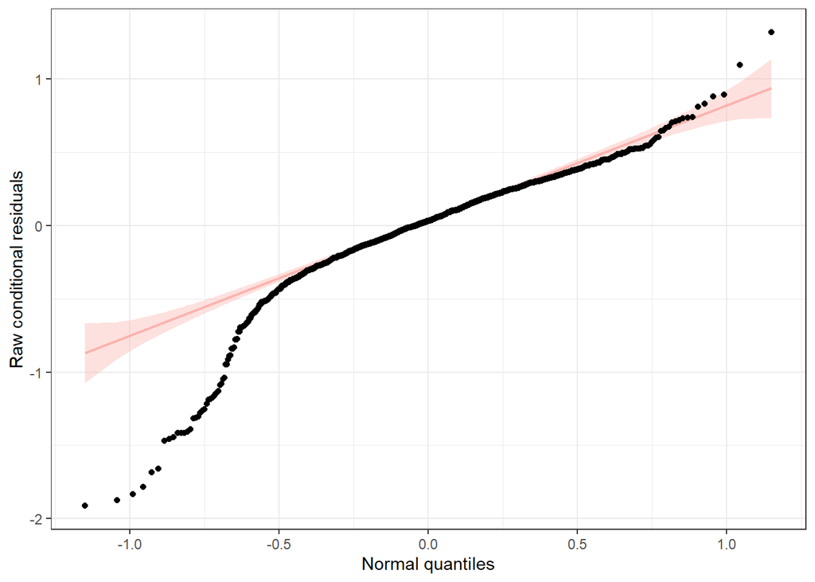

```r
plot_resqq(lmer.avg.v) #normality of residuals. #not great..
```

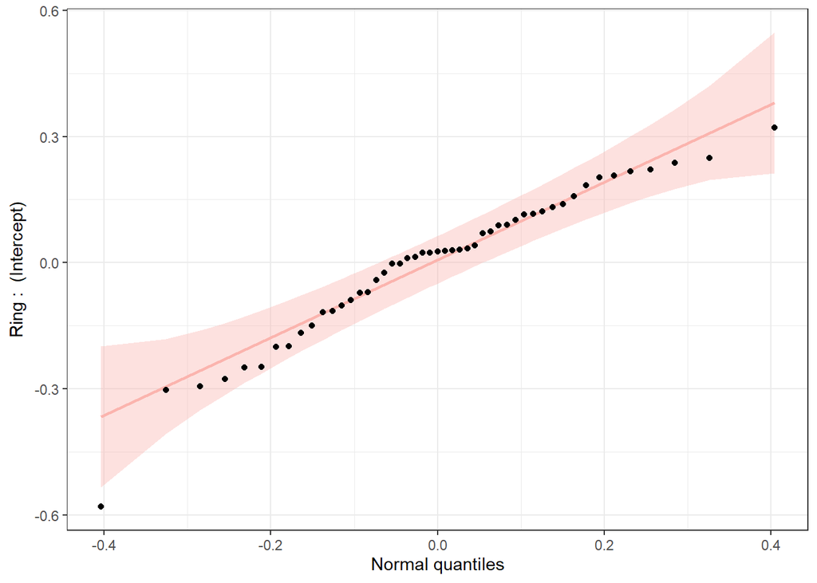

```r
plot_ranef(lmer.avg.v) #normality of random effects residuals
```

#### acceleration

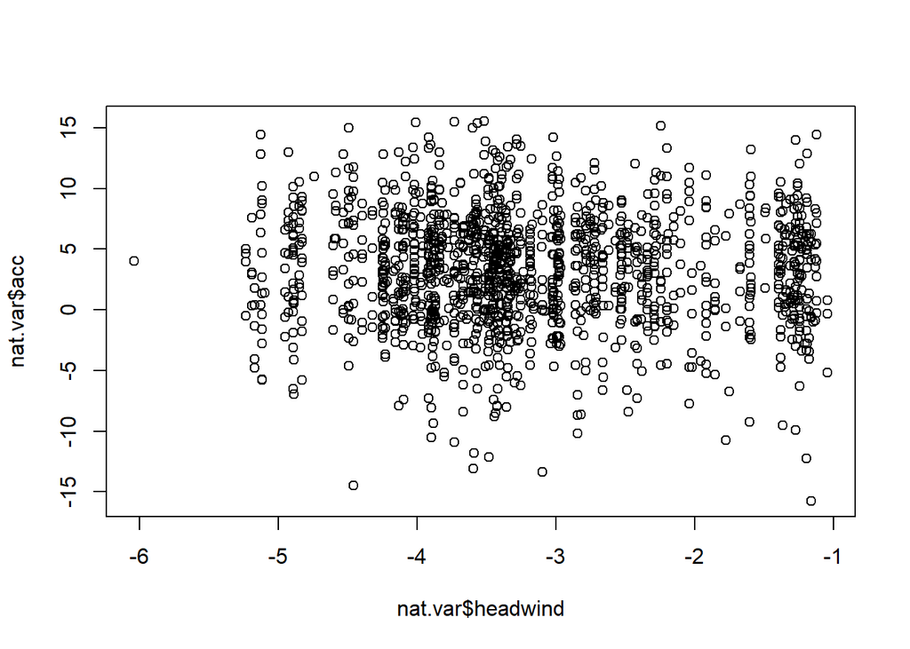

```r
plot(nat.var$headwind, nat.var$acc)
```

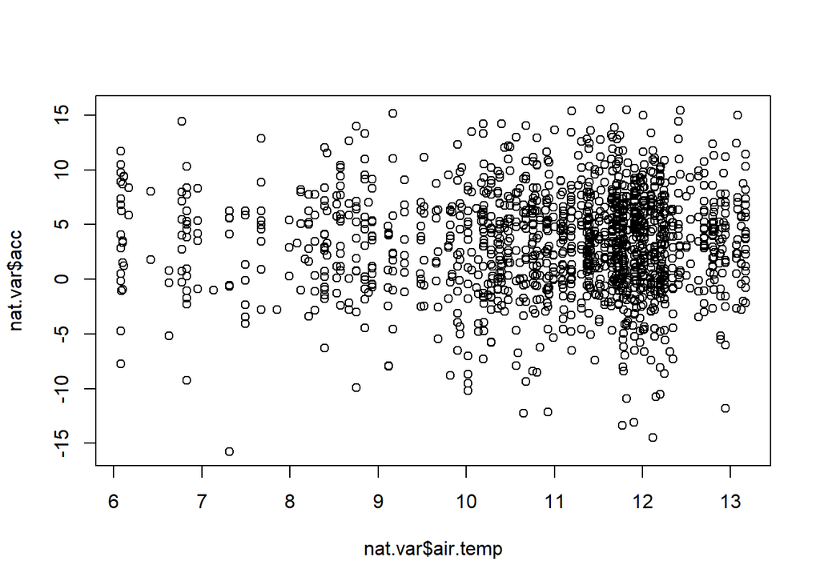

```r
plot(nat.var$air.temp, nat.var$acc) #better linearity
```

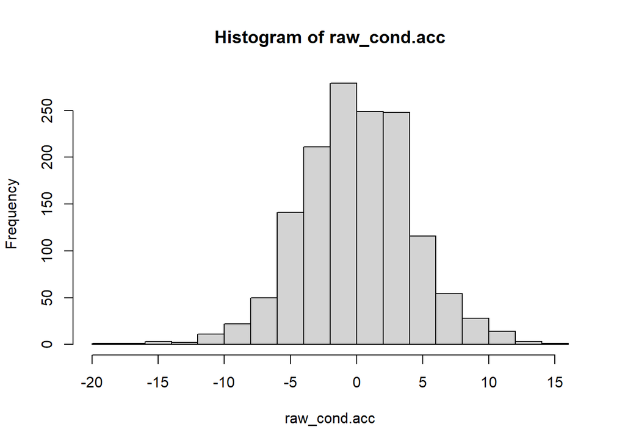

```r
hist(raw_cond.acc) #normality in histogram
```